# Elsevier 2022 SDG mapping

)

OR TITLE-ABS

(

"public understanding of climate change"

)

OR AUTHKEY

(

"public understanding of climate change"

)

OR TITLE-ABS

(

"education for the environment"

)

OR AUTHKEY

(

"education for the environment"

)

OR

(

TITLE-ABS

(

"earth-literate"

)

OR TITLE-ABS

(

"earthliterate"

)

)

OR

(

AUTHKEY

(

"earth-literate"

)

OR AUTHKEY

(

"earthliterate"

)

)

OR TITLE-ABS

(

"energy literacy"

)

OR AUTHKEY

(

"energy literacy"

)

OR TITLE-ABS

(

"awareness of sustainable development"

)

OR AUTHKEY

(

"awareness of sustainable development"

)

OR TITLE-ABS

(

"sustainable development education"

)

OR AUTHKEY

(

"sustainable development education"

)

OR TITLE-ABS

(

"earthkeepers"

)

OR AUTHKEY

(

"earthkeepers"

)

OR TITLE-ABS

(

"climate* change* aware*"

)

OR AUTHKEY

(

"climate* change* aware*"

)

OR TITLE-ABS

(

"Green curricula"

)

OR AUTHKEY

(

"Green curricula"

)

OR TITLE-ABS

(

"sustainability curriculum"

)

OR AUTHKEY

(

"sustainability curriculum"

)

OR TITLE-ABS

(

"conservation education"

)

OR AUTHKEY

(

"conservation education"

)

OR

(

TITLE-ABS

(

"energy-related behaviour"

)

OR TITLE-ABS

(

"energyrelated behaviour"

)

)

OR

(

AUTHKEY

(

"energy-related behaviour"

)

OR AUTHKEY

(

"energyrelated behaviour"

)

)

)

)

OR

(

(

(

(

TITLE-ABS("support sustainable production") AND (TITLE-ABS("developing country") OR TITLE-ABS("developing countries") OR TITLE-ABS("least-developed countries") OR TITLE-ABS("low income"))

)

OR

(

TITLE-ABS("support sustainable production") AND (TITLE-ABS("developing country") OR TITLE-ABS("developing countries") OR TITLE-ABS("leastdeveloped countries") OR TITLE-ABS("low income"))

)

)

OR

(

(

AUTHKEY("support sustainable production") AND (AUTHKEY("developing country") OR AUTHKEY("developing countries") OR AUTHKEY("least-developed countries") OR AUTHKEY("low income"))

)

OR

(

AUTHKEY("support sustainable production") AND (AUTHKEY("developing country") OR AUTHKEY("developing countries") OR AUTHKEY("leastdeveloped countries") OR AUTHKEY("low income"))

)

)

OR

(

(

TITLE-ABS("United Nations Development Programme") AND (TITLE-ABS("sustainability") OR TITLE-ABS("sustainable development") OR TITLE-ABS("sustainable consumption") OR TITLE-ABS("sustainable production") OR TITLE-ABS("clean energy") OR TITLE-ABS("global warming")) AND (TITLE-ABS("developing* countr*") OR TITLE-ABS("least*-developed* countr*") OR TITLE-ABS("low income"))

)

OR

(

TITLE-ABS("United Nations Development Programme") AND (TITLE-ABS("sustainability") OR TITLE-ABS("sustainable development") OR TITLE-ABS("sustainable consumption") OR TITLE-ABS("sustainable production") OR TITLE-ABS("clean energy") OR TITLE-ABS("global warming")) AND (TITLE-ABS("developing* countr*") OR TITLE-ABS("leastdeveloped* countr*") OR TITLE-ABS("low income"))

)

)

OR

(

(

AUTHKEY("United Nations Development Programme") AND (AUTHKEY("sustainability") OR AUTHKEY("sustainable development") OR AUTHKEY("sustainable consumption") OR AUTHKEY("sustainable production") OR AUTHKEY("clean energy") OR AUTHKEY("global warming")) AND (AUTHKEY("developing* countr*") OR AUTHKEY("least*-developed* countr*") OR AUTHKEY("low income"))

)

OR

(

AUTHKEY("United Nations Development Programme") AND (AUTHKEY("sustainability") OR AUTHKEY("sustainable development") OR AUTHKEY("sustainable consumption") OR AUTHKEY("sustainable production") OR AUTHKEY("clean energy") OR AUTHKEY("global warming")) AND (AUTHKEY("developing* countr*") OR AUTHKEY("leastdeveloped* countr*") OR AUTHKEY("low income"))

)

)

OR

(

TITLE-ABS

(

"official development assistance"

)

AND

(

TITLE-ABS("sustainability") OR TITLE-ABS("sustainable development") OR TITLE-ABS("sustainable consumption") OR TITLE-ABS("sustainable production") OR TITLE-ABS("clean energy") OR TITLE-ABS("global warming")

)

)

OR

(

AUTHKEY

(

"official development assistance"

)

AND

(

AUTHKEY("sustainability") OR AUTHKEY("sustainable development") OR AUTHKEY("sustainable consumption") OR AUTHKEY("sustainable production") OR AUTHKEY("clean energy") OR AUTHKEY("global warming")

)

)

OR

(

(

TITLE-ABS("knowledge transfer") AND (TITLE-ABS("sustainability") OR TITLE-ABS("sustainable development") OR TITLE-ABS("sustainable consumption") OR TITLE-ABS("sustainable production") OR TITLE-ABS("clean energy") OR TITLE-ABS("global warming")) AND (TITLE-ABS("developing* countr*") OR TITLE-ABS("least*-developed* countr*") OR TITLE-ABS("low income"))

)

OR

(

TITLE-ABS("knowledge transfer") AND (TITLE-ABS("sustainability") OR TITLE-ABS("sustainable development") OR TITLE-ABS("sustainable consumption") OR TITLE-ABS("sustainable production") OR TITLE-ABS("clean energy") OR TITLE-ABS("global warming")) AND (TITLE-ABS("developing* countr*") OR TITLE-ABS("leastdeveloped* countr*") OR TITLE-ABS("low income"))

)

)

OR

(

(

AUTHKEY("knowledge transfer") AND (AUTHKEY("sustainability") OR AUTHKEY("sustainable development") OR AUTHKEY("sustainable consumption") OR AUTHKEY("sustainable production") OR AUTHKEY("clean energy") OR AUTHKEY("global warming")) AND (AUTHKEY("developing* countr*") OR AUTHKEY("least*-developed* countr*") OR AUTHKEY("low income"))

)

OR

(

AUTHKEY("knowledge transfer") AND (AUTHKEY("sustainability") OR AUTHKEY("sustainable development") OR AUTHKEY("sustainable consumption") OR AUTHKEY("sustainable production") OR AUTHKEY("clean energy") OR AUTHKEY("global warming")) AND (AUTHKEY("developing* countr*") OR AUTHKEY("leastdeveloped* countr*") OR AUTHKEY("low income"))

)

)

OR

(

(

TITLE-ABS("scientific capacity") AND (TITLE-ABS("sustainability") OR TITLE-ABS("sustainable development") OR TITLE-ABS("sustainable consumption") OR TITLE-ABS("sustainable production") OR TITLE-ABS("clean energy") OR TITLE-ABS("global warming")) AND (TITLE-ABS("developing* countr*") OR TITLE-ABS("least*-developed* countr*") OR TITLE-ABS("low income"))

)

OR

(

TITLE-ABS("scientific capacity") AND (TITLE-ABS("sustainability") OR TITLE-ABS("sustainable development") OR TITLE-ABS("sustainable consumption") OR TITLE-ABS("sustainable production") OR TITLE-ABS("clean energy") OR TITLE-ABS("global warming")) AND (TITLE-ABS("developing* countr*") OR TITLE-ABS("leastdeveloped* countr*") OR TITLE-ABS("low income"))

)

)

OR

(

(

AUTHKEY("scientific capacity") AND (AUTHKEY("sustainability") OR AUTHKEY("sustainable development") OR AUTHKEY("sustainable consumption") OR AUTHKEY("sustainable production") OR AUTHKEY("clean energy") OR AUTHKEY("global warming")) AND (AUTHKEY("developing* countr*") OR AUTHKEY("least*-developed* countr*") OR AUTHKEY("low income"))

)

OR

(

AUTHKEY("scientific capacity") AND (AUTHKEY("sustainability") OR AUTHKEY("sustainable development") OR AUTHKEY("sustainable consumption") OR AUTHKEY("sustainable production") OR AUTHKEY("clean energy") OR AUTHKEY("global warming")) AND (AUTHKEY("developing* countr*") OR AUTHKEY("leastdeveloped* countr*") OR AUTHKEY("low income"))

)

)

OR

(

(

TITLE-ABS("United States Agency for International Development") AND (TITLE-ABS("sustainability") OR TITLE-ABS("sustainable development") OR TITLE-ABS("sustainable consumption") OR TITLE-ABS("sustainable production") OR TITLE-ABS("clean energy") OR TITLE-ABS("global warming")) AND (TITLE-ABS("developing* countr*") OR TITLE-ABS("least*-developed* countr*") OR TITLE-ABS("low income"))

)

OR

(

TITLE-ABS("United States Agency for International Development") AND (TITLE-ABS("sustainability") OR TITLE-ABS("sustainable development") OR TITLE-ABS("sustainable consumption") OR TITLE-ABS("sustainable production") OR TITLE-ABS("clean energy") OR TITLE-ABS("global warming")) AND (TITLE-ABS("developing* countr*") OR TITLE-ABS("leastdeveloped* countr*") OR TITLE-ABS("low income"))

)

)

OR

(

(

AUTHKEY("United States Agency for International Development") AND (AUTHKEY("sustainability") OR AUTHKEY("sustainable development") OR AUTHKEY("sustainable consumption") OR AUTHKEY("sustainable production") OR AUTHKEY("clean energy") OR AUTHKEY("global warming")) AND (AUTHKEY("developing* countr*") OR AUTHKEY("least*-developed* countr*") OR AUTHKEY("low income"))

)

OR

(

AUTHKEY("United States Agency for International Development") AND (AUTHKEY("sustainability") OR AUTHKEY("sustainable development") OR AUTHKEY("sustainable consumption") OR AUTHKEY("sustainable production") OR AUTHKEY("clean energy") OR AUTHKEY("global warming")) AND (AUTHKEY("developing* countr*") OR AUTHKEY("leastdeveloped* countr*") OR AUTHKEY("low income"))

)

)

OR

(

(

TITLE-ABS("technological capacity") AND (TITLE-ABS("sustainability") OR TITLE-ABS("sustainable development") OR TITLE-ABS("sustainable consumption") OR TITLE-ABS("sustainable production") OR TITLE-ABS("clean energy") OR TITLE-ABS("global warming")) AND (TITLE-ABS("developing* countr*") OR TITLE-ABS("least*-developed* countr*") OR TITLE-ABS("low income"))

)

OR

(

TITLE-ABS("technological capacity") AND (TITLE-ABS("sustainability") OR TITLE-ABS("sustainable development") OR TITLE-ABS("sustainable consumption") OR TITLE-ABS("sustainable production") OR TITLE-ABS("clean energy") OR TITLE-ABS("global warming")) AND (TITLE-ABS("developing* countr*") OR TITLE-ABS("leastdeveloped* countr*") OR TITLE-ABS("low income"))

)

)

OR

(

(

AUTHKEY("technological capacity") AND (AUTHKEY("sustainability") OR AUTHKEY("sustainable development") OR AUTHKEY("sustainable consumption") OR AUTHKEY("sustainable production") OR AUTHKEY("clean energy") OR AUTHKEY("global warming")) AND (AUTHKEY("developing* countr*") OR AUTHKEY("least*-developed* countr*") OR AUTHKEY("low income"))

)

OR

(

AUTHKEY("technological capacity") AND (AUTHKEY("sustainability") OR AUTHKEY("sustainable development") OR AUTHKEY("sustainable consumption") OR AUTHKEY("sustainable production") OR AUTHKEY("clean energy") OR AUTHKEY("global warming")) AND (AUTHKEY("developing* countr*") OR AUTHKEY("leastdeveloped* countr*") OR AUTHKEY("low income"))

)

)

OR

(

(

TITLE-ABS("capacity strengthening") AND (TITLE-ABS("sustainability") OR TITLE-ABS("sustainable development") OR TITLE-ABS("sustainable consumption") OR TITLE-ABS("sustainable production") OR TITLE-ABS("clean energy") OR TITLE-ABS("global warming")) AND (TITLE-ABS("developing* countr*") OR TITLE-ABS("least*-developed* countr*") OR TITLE-ABS("low income"))

)

OR

(

TITLE-ABS("capacity strengthening") AND (TITLE-ABS("sustainability") OR TITLE-ABS("sustainable development") OR TITLE-ABS("sustainable consumption") OR TITLE-ABS("sustainable production") OR TITLE-ABS("clean energy") OR TITLE-ABS("global warming")) AND (TITLE-ABS("developing* countr*") OR TITLE-ABS("leastdeveloped* countr*") OR TITLE-ABS("low income"))

)

)

OR

(

(

AUTHKEY("capacity strengthening") AND (AUTHKEY("sustainability") OR AUTHKEY("sustainable development") OR AUTHKEY("sustainable consumption") OR AUTHKEY("sustainable production") OR AUTHKEY("clean energy") OR AUTHKEY("global warming")) AND (AUTHKEY("developing* countr*") OR AUTHKEY("least*-developed* countr*") OR AUTHKEY("low income"))

)

OR

(

AUTHKEY("capacity strengthening") AND (AUTHKEY("sustainability") OR AUTHKEY("sustainable development") OR AUTHKEY("sustainable consumption") OR AUTHKEY("sustainable production") OR AUTHKEY("clean energy") OR AUTHKEY("global warming")) AND (AUTHKEY("developing* countr*") OR AUTHKEY("leastdeveloped* countr*") OR AUTHKEY("low income"))

)

)

OR TITLE-ABS

(

"development mechanism

(

cdm

)

"

)

OR AUTHKEY

(

"development mechanism

(

cdm

)

"

)

OR

(

(

TITLE-ABS("transfer of knowledge") AND (TITLE-ABS("sustainability") OR TITLE-ABS("sustainable development") OR TITLE-ABS("sustainable consumption") OR TITLE-ABS("sustainable production") OR TITLE-ABS("clean energy") OR TITLE-ABS("global warming")) AND (TITLE-ABS("developing* countr*") OR TITLE-ABS("least*-developed* countr*") OR TITLE-ABS("low income"))

)

OR

(

TITLE-ABS("transfer of knowledge") AND (TITLE-ABS("sustainability") OR TITLE-ABS("sustainable development") OR TITLE-ABS("sustainable consumption") OR TITLE-ABS("sustainable production") OR TITLE-ABS("clean energy") OR TITLE-ABS("global warming")) AND (TITLE-ABS("developing* countr*") OR TITLE-ABS("leastdeveloped* countr*") OR TITLE-ABS("low income"))

)

)

OR

(

(

AUTHKEY("transfer of knowledge") AND (AUTHKEY("sustainability") OR AUTHKEY("sustainable development") OR AUTHKEY("sustainable consumption") OR AUTHKEY("sustainable production") OR AUTHKEY("clean energy") OR AUTHKEY("global warming")) AND (AUTHKEY("developing* countr*") OR AUTHKEY("least*-developed* countr*") OR AUTHKEY("low income"))

)

OR

(

AUTHKEY("transfer of knowledge") AND (AUTHKEY("sustainability") OR AUTHKEY("sustainable development") OR AUTHKEY("sustainable consumption") OR AUTHKEY("sustainable production") OR AUTHKEY("clean energy") OR AUTHKEY("global warming")) AND (AUTHKEY("developing* countr*") OR AUTHKEY("leastdeveloped* countr*") OR AUTHKEY("low income"))

)

)

OR

(

(

TITLE-ABS("cooperation for development") AND (TITLE-ABS("sustainability") OR TITLE-ABS("sustainable development") OR TITLE-ABS("sustainable consumption") OR TITLE-ABS("sustainable production") OR TITLE-ABS("clean energy") OR TITLE-ABS("global warming")) AND (TITLE-ABS("developing* countr*") OR TITLE-ABS("least*-developed* countr*") OR TITLE-ABS("low income"))

)

OR

(

TITLE-ABS("cooperation for development") AND (TITLE-ABS("sustainability") OR TITLE-ABS("sustainable development") OR TITLE-ABS("sustainable consumption") OR TITLE-ABS("sustainable production") OR TITLE-ABS("clean energy") OR TITLE-ABS("global warming")) AND (TITLE-ABS("developing* countr*") OR TITLE-ABS("leastdeveloped* countr*") OR TITLE-ABS("low income"))

)

)

OR

(

(

AUTHKEY("cooperation for development") AND (AUTHKEY("sustainability") OR AUTHKEY("sustainable development") OR AUTHKEY("sustainable consumption") OR AUTHKEY("sustainable production") OR AUTHKEY("clean energy") OR AUTHKEY("global warming")) AND (AUTHKEY("developing* countr*") OR AUTHKEY("least*-developed* countr*") OR AUTHKEY("low income"))

)

OR

(

AUTHKEY("cooperation for development") AND (AUTHKEY("sustainability") OR AUTHKEY("sustainable development") OR AUTHKEY("sustainable consumption") OR AUTHKEY("sustainable production") OR AUTHKEY("clean energy") OR AUTHKEY("global warming")) AND (AUTHKEY("developing* countr*") OR AUTHKEY("leastdeveloped* countr*") OR AUTHKEY("low income"))

)

)

OR

(

(

TITLE-ABS("technology transfer") AND (TITLE-ABS("sustainability") OR TITLE-ABS("sustainable development") OR TITLE-ABS("sustainable consumption") OR TITLE-ABS("sustainable production") OR TITLE-ABS("clean energy") OR TITLE-ABS("global warming")) AND (TITLE-ABS("developing* countr*") OR TITLE-ABS("least*-developed* countr*") OR TITLE-ABS("low income"))

)

OR

(

TITLE-ABS("technology transfer") AND (TITLE-ABS("sustainability") OR TITLE-ABS("sustainable development") OR TITLE-ABS("sustainable consumption") OR TITLE-ABS("sustainable production") OR TITLE-ABS("clean energy") OR TITLE-ABS("global warming")) AND (TITLE-ABS("developing* countr*") OR TITLE-ABS("leastdeveloped* countr*") OR TITLE-ABS("low income"))

)

)

OR

(

(

AUTHKEY("technology transfer") AND (AUTHKEY("sustainability") OR AUTHKEY("sustainable development") OR AUTHKEY("sustainable consumption") OR AUTHKEY("sustainable production") OR AUTHKEY("clean energy") OR AUTHKEY("global warming")) AND (AUTHKEY("developing* countr*") OR AUTHKEY("least*-developed* countr*") OR AUTHKEY("low income"))

)

OR

(

AUTHKEY("technology transfer") AND (AUTHKEY("sustainability") OR AUTHKEY("sustainable development") OR AUTHKEY("sustainable consumption") OR AUTHKEY("sustainable production") OR AUTHKEY("clean energy") OR AUTHKEY("global warming")) AND (AUTHKEY("developing* countr*") OR AUTHKEY("leastdeveloped* countr*") OR AUTHKEY("low income"))

)

)

OR

(

TITLE-ABS

(

"international aid"

)

AND

(

TITLE-ABS("sustainability") OR TITLE-ABS("sustainable development") OR TITLE-ABS("sustainable consumption") OR TITLE-ABS("sustainable production") OR TITLE-ABS("clean energy") OR TITLE-ABS("global warming")

)

)

OR

(

AUTHKEY

(

"international aid"

)

AND

(

AUTHKEY("sustainability") OR AUTHKEY("sustainable development") OR AUTHKEY("sustainable consumption") OR AUTHKEY("sustainable production") OR AUTHKEY("clean energy") OR AUTHKEY("global warming")

)

)

OR

(

(

TITLE-ABS("Global Environment Facility") AND (TITLE-ABS("developing* countr*") OR TITLE-ABS("least*-developed* countr*") OR TITLE-ABS("low income"))

)

OR

(

TITLE-ABS("Global Environment Facility") AND (TITLE-ABS("developing* countr*") OR TITLE-ABS("leastdeveloped* countr*") OR TITLE-ABS("low income"))

)

)

OR

(

(

AUTHKEY("Global Environment Facility") AND (AUTHKEY("developing* countr*") OR AUTHKEY("least*-developed* countr*") OR AUTHKEY("low income"))

)

OR

(

AUTHKEY("Global Environment Facility") AND (AUTHKEY("developing* countr*") OR AUTHKEY("leastdeveloped* countr*") OR AUTHKEY("low income"))

)

)

OR

(

TITLE-ABS

(

"Development aid"

)

AND

(

TITLE-ABS("sustainability") OR TITLE-ABS("sustainable development") OR TITLE-ABS("sustainable consumption") OR TITLE-ABS("sustainable production") OR TITLE-ABS("clean energy") OR TITLE-ABS("global warming")

)

)

OR

(

AUTHKEY

(

"Development aid"

)

AND

(

AUTHKEY("sustainability") OR AUTHKEY("sustainable development") OR AUTHKEY("sustainable consumption") OR AUTHKEY("sustainable production") OR AUTHKEY("clean energy") OR AUTHKEY("global warming")

)

)

OR

(

TITLE-ABS

(

"foreign aid"

)

AND

(

TITLE-ABS("sustainability") OR TITLE-ABS("sustainable development") OR TITLE-ABS("sustainable consumption") OR TITLE-ABS("sustainable production") OR TITLE-ABS("clean energy") OR TITLE-ABS("global warming")

)

)

OR

(

AUTHKEY

(

"foreign aid"

)

AND

(

AUTHKEY("sustainability") OR AUTHKEY("sustainable development") OR AUTHKEY("sustainable consumption") OR AUTHKEY("sustainable production") OR AUTHKEY("clean energy") OR AUTHKEY("global warming")

)

)

OR

(

(

TITLE-ABS("UNDP") AND (TITLE-ABS("sustainability") OR TITLE-ABS("sustainable development") OR TITLE-ABS("sustainable consumption") OR TITLE-ABS("sustainable production") OR TITLE-ABS("clean energy") OR TITLE-ABS("global warming")) AND (TITLE-ABS("developing* countr*") OR TITLE-ABS("least*-developed* countr*") OR TITLE-ABS("low income"))

)

OR

(

TITLE-ABS("UNDP") AND (TITLE-ABS("sustainability") OR TITLE-ABS("sustainable development") OR TITLE-ABS("sustainable consumption") OR TITLE-ABS("sustainable production") OR TITLE-ABS("clean energy") OR TITLE-ABS("global warming")) AND (TITLE-ABS("developing* countr*") OR TITLE-ABS("leastdeveloped* countr*") OR TITLE-ABS("low income"))

)

)

OR

(

(

AUTHKEY("UNDP") AND (AUTHKEY("sustainability") OR AUTHKEY("sustainable development") OR AUTHKEY("sustainable consumption") OR AUTHKEY("sustainable production") OR AUTHKEY("clean energy") OR AUTHKEY("global warming")) AND (AUTHKEY("developing* countr*") OR AUTHKEY("least*-developed* countr*") OR AUTHKEY("low income"))

)

OR

(

AUTHKEY("UNDP") AND (AUTHKEY("sustainability") OR AUTHKEY("sustainable development") OR AUTHKEY("sustainable consumption") OR AUTHKEY("sustainable production") OR AUTHKEY("clean energy") OR AUTHKEY("global warming")) AND (AUTHKEY("developing* countr*") OR AUTHKEY("leastdeveloped* countr*") OR AUTHKEY("low income"))

)

)

OR

(

(

TITLE-ABS("foster sustainable development") AND (TITLE-ABS("developing country") OR TITLE-ABS("developing countries") OR TITLE-ABS("least-developed countries") OR TITLE-ABS("low income"))

)

OR

(

TITLE-ABS("foster sustainable development") AND (TITLE-ABS("developing country") OR TITLE-ABS("developing countries") OR TITLE-ABS("leastdeveloped countries") OR TITLE-ABS("low income"))

)

)

OR

(

(

AUTHKEY("foster sustainable development") AND (AUTHKEY("developing country") OR AUTHKEY("developing countries") OR AUTHKEY("least-developed countries") OR AUTHKEY("low income"))

)

OR

(

AUTHKEY("foster sustainable development") AND (AUTHKEY("developing country") OR AUTHKEY("developing countries") OR AUTHKEY("leastdeveloped countries") OR AUTHKEY("low income"))

)

)

OR

(

TITLE-ABS

(

"development assistance"

)

AND

(

TITLE-ABS("sustainability") OR TITLE-ABS("sustainable development") OR TITLE-ABS("sustainable consumption") OR TITLE-ABS("sustainable production") OR TITLE-ABS("clean energy") OR TITLE-ABS("global warming")

)

)

OR

(

AUTHKEY

(

"development assistance"

)

AND

(

AUTHKEY("sustainability") OR AUTHKEY("sustainable development") OR AUTHKEY("sustainable consumption") OR AUTHKEY("sustainable production") OR AUTHKEY("clean energy") OR AUTHKEY("global warming")

)

)

OR

(

(

TITLE-ABS("capacity building") AND (TITLE-ABS("sustainability") OR TITLE-ABS("sustainable development") OR TITLE-ABS("sustainable consumption") OR TITLE-ABS("sustainable production") OR TITLE-ABS("clean energy") OR TITLE-ABS("global warming")) AND (TITLE-ABS("developing* countr*") OR TITLE-ABS("least*-developed* countr*") OR TITLE-ABS("low income"))

)

OR

(

TITLE-ABS("capacity building") AND (TITLE-ABS("sustainability") OR TITLE-ABS("sustainable development") OR TITLE-ABS("sustainable consumption") OR TITLE-ABS("sustainable production") OR TITLE-ABS("clean energy") OR TITLE-ABS("global warming")) AND (TITLE-ABS("developing* countr*") OR TITLE-ABS("leastdeveloped* countr*") OR TITLE-ABS("low income"))

)

)

OR

(

(

AUTHKEY("capacity building") AND (AUTHKEY("sustainability") OR AUTHKEY("sustainable development") OR AUTHKEY("sustainable consumption") OR AUTHKEY("sustainable production") OR AUTHKEY("clean energy") OR AUTHKEY("global warming")) AND (AUTHKEY("developing* countr*") OR AUTHKEY("least*-developed* countr*") OR AUTHKEY("low income"))

)

OR

(

AUTHKEY("capacity building") AND (AUTHKEY("sustainability") OR AUTHKEY("sustainable development") OR AUTHKEY("sustainable consumption") OR AUTHKEY("sustainable production") OR AUTHKEY("clean energy") OR AUTHKEY("global warming")) AND (AUTHKEY("developing* countr*") OR AUTHKEY("leastdeveloped* countr*") OR AUTHKEY("low income"))

)

)

OR

(

(

TITLE-ABS("development capacity") AND (TITLE-ABS("sustainability") OR TITLE-ABS("sustainable development") OR TITLE-ABS("sustainable consumption") OR TITLE-ABS("sustainable production") OR TITLE-ABS("clean energy") OR TITLE-ABS("global warming")) AND (TITLE-ABS("developing* countr*") OR TITLE-ABS("least*-developed* countr*") OR TITLE-ABS("low income"))

)

OR

(

TITLE-ABS("development capacity") AND (TITLE-ABS("sustainability") OR TITLE-ABS("sustainable development") OR TITLE-ABS("sustainable consumption") OR TITLE-ABS("sustainable production") OR TITLE-ABS("clean energy") OR TITLE-ABS("global warming")) AND (TITLE-ABS("developing* countr*") OR TITLE-ABS("leastdeveloped* countr*") OR TITLE-ABS("low income"))

)

)

OR

(

(

AUTHKEY("development capacity") AND (AUTHKEY("sustainability") OR AUTHKEY("sustainable development") OR AUTHKEY("sustainable consumption") OR AUTHKEY("sustainable production") OR AUTHKEY("clean energy") OR AUTHKEY("global warming")) AND (AUTHKEY("developing* countr*") OR AUTHKEY("least*-developed* countr*") OR AUTHKEY("low income"))

)

OR

(

AUTHKEY("development capacity") AND (AUTHKEY("sustainability") OR AUTHKEY("sustainable development") OR AUTHKEY("sustainable consumption") OR AUTHKEY("sustainable production") OR AUTHKEY("clean energy") OR AUTHKEY("global warming")) AND (AUTHKEY("developing* countr*") OR AUTHKEY("leastdeveloped* countr*") OR AUTHKEY("low income"))

)

)

OR

(

TITLE-ABS

(

"development cooperation"

)

AND

(

TITLE-ABS("sustainability") OR TITLE-ABS("sustainable development") OR TITLE-ABS("sustainable consumption") OR TITLE-ABS("sustainable production") OR TITLE-ABS("clean energy") OR TITLE-ABS("global warming")

)

)

OR

(

AUTHKEY

(

"development cooperation"

)

AND

(

AUTHKEY("sustainability") OR AUTHKEY("sustainable development") OR AUTHKEY("sustainable consumption") OR AUTHKEY("sustainable production") OR AUTHKEY("clean energy") OR AUTHKEY("global warming")

)

)

OR

(

(

TITLE-ABS("USAID") AND (TITLE-ABS("sustainability") OR TITLE-ABS("sustainable development") OR TITLE-ABS("sustainable consumption") OR TITLE-ABS("sustainable production") OR TITLE-ABS("clean energy") OR TITLE-ABS("global warming")) AND (TITLE-ABS("developing* countr*") OR TITLE-ABS("least*-developed* countr*") OR TITLE-ABS("low income"))

)

OR

(

TITLE-ABS("USAID") AND (TITLE-ABS("sustainability") OR TITLE-ABS("sustainable development") OR TITLE-ABS("sustainable consumption") OR TITLE-ABS("sustainable production") OR TITLE-ABS("clean energy") OR TITLE-ABS("global warming")) AND (TITLE-ABS("developing* countr*") OR TITLE-ABS("leastdeveloped* countr*") OR TITLE-ABS("low income"))

)

)

OR

(

(

AUTHKEY("USAID") AND (AUTHKEY("sustainability") OR AUTHKEY("sustainable development") OR AUTHKEY("sustainable consumption") OR AUTHKEY("sustainable production") OR AUTHKEY("clean energy") OR AUTHKEY("global warming")) AND (AUTHKEY("developing* countr*") OR AUTHKEY("least*-developed* countr*") OR AUTHKEY("low income"))

)

OR

(

AUTHKEY("USAID") AND (AUTHKEY("sustainability") OR AUTHKEY("sustainable development") OR AUTHKEY("sustainable consumption") OR AUTHKEY("sustainable production") OR AUTHKEY("clean energy") OR AUTHKEY("global warming")) AND (AUTHKEY("developing* countr*") OR AUTHKEY("leastdeveloped* countr*") OR AUTHKEY("low income"))

)

)

OR

(

(

TITLE-ABS("international cooperation") AND (TITLE-ABS("sustainability") OR TITLE-ABS("sustainable development") OR TITLE-ABS("sustainable consumption") OR TITLE-ABS("sustainable production") OR TITLE-ABS("clean energy") OR TITLE-ABS("global warming")) AND (TITLE-ABS("developing* countr*") OR TITLE-ABS("least*-developed* countr*") OR TITLE-ABS("low income"))

)

OR

(

TITLE-ABS("international cooperation") AND (TITLE-ABS("sustainability") OR TITLE-ABS("sustainable development") OR TITLE-ABS("sustainable consumption") OR TITLE-ABS("sustainable production") OR TITLE-ABS("clean energy") OR TITLE-ABS("global warming")) AND (TITLE-ABS("developing* countr*") OR TITLE-ABS("leastdeveloped* countr*") OR TITLE-ABS("low income"))

)

)

OR

(

(

AUTHKEY("international cooperation") AND (AUTHKEY("sustainability") OR AUTHKEY("sustainable development") OR AUTHKEY("sustainable consumption") OR AUTHKEY("sustainable production") OR AUTHKEY("clean energy") OR AUTHKEY("global warming")) AND (AUTHKEY("developing* countr*") OR AUTHKEY("least*-developed* countr*") OR AUTHKEY("low income"))

)

OR

(

AUTHKEY("international cooperation") AND (AUTHKEY("sustainability") OR AUTHKEY("sustainable development") OR AUTHKEY("sustainable consumption") OR AUTHKEY("sustainable production") OR AUTHKEY("clean energy") OR AUTHKEY("global warming")) AND (AUTHKEY("developing* countr*") OR AUTHKEY("leastdeveloped* countr*") OR AUTHKEY("low income"))

)

)

OR TITLE-ABS

(

"cdm projects"

)

OR AUTHKEY

(

"cdm projects"

)

OR

(

TITLE-ABS

(

"overseas aid"

)

AND

(

TITLE-ABS("sustainability") OR TITLE-ABS("sustainable development") OR TITLE-ABS("sustainable consumption") OR TITLE-ABS("sustainable production") OR TITLE-ABS("clean energy") OR TITLE-ABS("global warming")

)

)

OR

(

AUTHKEY

(

"overseas aid"

)

AND

(

AUTHKEY("sustainability") OR AUTHKEY("sustainable development") OR AUTHKEY("sustainable consumption") OR AUTHKEY("sustainable production") OR AUTHKEY("clean energy") OR AUTHKEY("global warming")

)

)

OR

(

(

TITLE-ABS("technology capacity") AND (TITLE-ABS("sustainability") OR TITLE-ABS("sustainable development") OR TITLE-ABS("sustainable consumption") OR TITLE-ABS("sustainable production") OR TITLE-ABS("clean energy") OR TITLE-ABS("global warming")) AND (TITLE-ABS("developing* countr*") OR TITLE-ABS("least*-developed* countr*") OR TITLE-ABS("low income"))

)

OR

(

TITLE-ABS("technology capacity") AND (TITLE-ABS("sustainability") OR TITLE-ABS("sustainable development") OR TITLE-ABS("sustainable consumption") OR TITLE-ABS("sustainable production") OR TITLE-ABS("clean energy") OR TITLE-ABS("global warming")) AND (TITLE-ABS("developing* countr*") OR TITLE-ABS("leastdeveloped* countr*") OR TITLE-ABS("low income"))

)

)

OR

(

(

AUTHKEY("technology capacity") AND (AUTHKEY("sustainability") OR AUTHKEY("sustainable development") OR AUTHKEY("sustainable consumption") OR AUTHKEY("sustainable production") OR AUTHKEY("clean energy") OR AUTHKEY("global warming")) AND (AUTHKEY("developing* countr*") OR AUTHKEY("least*-developed* countr*") OR AUTHKEY("low income"))

)

OR

(

AUTHKEY("technology capacity") AND (AUTHKEY("sustainability") OR AUTHKEY("sustainable development") OR AUTHKEY("sustainable consumption") OR AUTHKEY("sustainable production") OR AUTHKEY("clean energy") OR AUTHKEY("global warming")) AND (AUTHKEY("developing* countr*") OR AUTHKEY("leastdeveloped* countr*") OR AUTHKEY("low income"))

)

)

OR

(

(

TITLE-ABS("enable sustainable development") AND (TITLE-ABS("developing country") OR TITLE-ABS("developing countries") OR TITLE-ABS("least-developed countries") OR TITLE-ABS("low income"))

)

OR

(

TITLE-ABS("enable sustainable development") AND (TITLE-ABS("developing country") OR TITLE-ABS("developing countries") OR TITLE-ABS("leastdeveloped countries") OR TITLE-ABS("low income"))

)

)

OR

(

(

AUTHKEY("enable sustainable development") AND (AUTHKEY("developing country") OR AUTHKEY("developing countries") OR AUTHKEY("least-developed countries") OR AUTHKEY("low income"))

)

OR

(

AUTHKEY("enable sustainable development") AND (AUTHKEY("developing country") OR AUTHKEY("developing countries") OR AUTHKEY("leastdeveloped countries") OR AUTHKEY("low income"))

)

)

OR

(

(

TITLE-ABS("capacity development") AND (TITLE-ABS("sustainability") OR TITLE-ABS("sustainable development") OR TITLE-ABS("sustainable consumption") OR TITLE-ABS("sustainable production") OR TITLE-ABS("clean energy") OR TITLE-ABS("global warming")) AND (TITLE-ABS("developing* countr*") OR TITLE-ABS("least*-developed* countr*") OR TITLE-ABS("low income"))

)

OR

(

TITLE-ABS("capacity development") AND (TITLE-ABS("sustainability") OR TITLE-ABS("sustainable development") OR TITLE-ABS("sustainable consumption") OR TITLE-ABS("sustainable production") OR TITLE-ABS("clean energy") OR TITLE-ABS("global warming")) AND (TITLE-ABS("developing* countr*") OR TITLE-ABS("leastdeveloped* countr*") OR TITLE-ABS("low income"))

)

)

OR

(

(

AUTHKEY("capacity development") AND (AUTHKEY("sustainability") OR AUTHKEY("sustainable development") OR AUTHKEY("sustainable consumption") OR AUTHKEY("sustainable production") OR AUTHKEY("clean energy") OR AUTHKEY("global warming")) AND (AUTHKEY("developing* countr*") OR AUTHKEY("least*-developed* countr*") OR AUTHKEY("low income"))

)

OR

(

AUTHKEY("capacity development") AND (AUTHKEY("sustainability") OR AUTHKEY("sustainable development") OR AUTHKEY("sustainable consumption") OR AUTHKEY("sustainable production") OR AUTHKEY("clean energy") OR AUTHKEY("global warming")) AND (AUTHKEY("developing* countr*") OR AUTHKEY("leastdeveloped* countr*") OR AUTHKEY("low income"))

)

)

OR

(

(

(TITLE-ABS("transfer of technology") OR TITLE-ABS("transfer of technologies")) AND (TITLE-ABS("sustainability") OR TITLE-ABS("sustainable development") OR TITLE-ABS("sustainable consumption") OR TITLE-ABS("sustainable production") OR TITLE-ABS("clean energy") OR TITLE-ABS("global warming")) AND (TITLE-ABS("developing* countr*") OR TITLE-ABS("least*-developed* countr*") OR TITLE-ABS("low income"))

)

OR

(

(TITLE-ABS("transfer of technology") OR TITLE-ABS("transfer of technologies")) AND (TITLE-ABS("sustainability") OR TITLE-ABS("sustainable development") OR TITLE-ABS("sustainable consumption") OR TITLE-ABS("sustainable production") OR TITLE-ABS("clean energy") OR TITLE-ABS("global warming")) AND (TITLE-ABS("developing* countr*") OR TITLE-ABS("leastdeveloped* countr*") OR TITLE-ABS("low income"))

)

)

OR

(

(

(AUTHKEY("transfer of technology") OR AUTHKEY("transfer of technologies")) AND (AUTHKEY("sustainability") OR AUTHKEY("sustainable development") OR AUTHKEY("sustainable consumption") OR AUTHKEY("sustainable production") OR AUTHKEY("clean energy") OR AUTHKEY("global warming")) AND (AUTHKEY("developing* countr*") OR AUTHKEY("least*-developed* countr*") OR AUTHKEY("low income"))

)

OR

(

(AUTHKEY("transfer of technology") OR AUTHKEY("transfer of technologies")) AND (AUTHKEY("sustainability") OR AUTHKEY("sustainable development") OR AUTHKEY("sustainable consumption") OR AUTHKEY("sustainable production") OR AUTHKEY("clean energy") OR AUTHKEY("global warming")) AND (AUTHKEY("developing* countr*") OR AUTHKEY("leastdeveloped* countr*") OR AUTHKEY("low income"))

)

)

OR TITLE-ABS

(

"cdm project"

)

OR AUTHKEY

(

"cdm project"

)

OR

(

TITLE-ABS

(

"clean development"

)

AND TITLE-ABS

(

"cdm"

)

)

OR

(

AUTHKEY

(

"clean development"

)

AND AUTHKEY

(

"cdm"

)

)

OR

(

(

TITLE-ABS("support sustainable development") AND (TITLE-ABS("developing country") OR TITLE-ABS("developing countries") OR TITLE-ABS("least-developed countries") OR TITLE-ABS("low income"))

)

OR

(

TITLE-ABS("support sustainable development") AND (TITLE-ABS("developing country") OR TITLE-ABS("developing countries") OR TITLE-ABS("leastdeveloped countries") OR TITLE-ABS("low income"))

)

)

OR

(

(

AUTHKEY("support sustainable development") AND (AUTHKEY("developing country") OR AUTHKEY("developing countries") OR AUTHKEY("least-developed countries") OR AUTHKEY("low income"))

)

OR

(

AUTHKEY("support sustainable development") AND (AUTHKEY("developing country") OR AUTHKEY("developing countries") OR AUTHKEY("leastdeveloped countries") OR AUTHKEY("low income"))

)

)

OR

(

(

TITLE-ABS("research capacity") AND (TITLE-ABS("sustainability") OR TITLE-ABS("sustainable development") OR TITLE-ABS("sustainable consumption") OR TITLE-ABS("sustainable production") OR TITLE-ABS("clean energy") OR TITLE-ABS("global warming")) AND (TITLE-ABS("developing* countr*") OR TITLE-ABS("least*-developed* countr*") OR TITLE-ABS("low income"))

)

OR

(

TITLE-ABS("research capacity") AND (TITLE-ABS("sustainability") OR TITLE-ABS("sustainable development") OR TITLE-ABS("sustainable consumption") OR TITLE-ABS("sustainable production") OR TITLE-ABS("clean energy") OR TITLE-ABS("global warming")) AND (TITLE-ABS("developing* countr*") OR TITLE-ABS("leastdeveloped* countr*") OR TITLE-ABS("low income"))

)

)

OR

(

(

AUTHKEY("research capacity") AND (AUTHKEY("sustainability") OR AUTHKEY("sustainable development") OR AUTHKEY("sustainable consumption") OR AUTHKEY("sustainable production") OR AUTHKEY("clean energy") OR AUTHKEY("global warming")) AND (AUTHKEY("developing* countr*") OR AUTHKEY("least*-developed* countr*") OR AUTHKEY("low income"))

)

OR

(

AUTHKEY("research capacity") AND (AUTHKEY("sustainability") OR AUTHKEY("sustainable development") OR AUTHKEY("sustainable consumption") OR AUTHKEY("sustainable production") OR AUTHKEY("clean energy") OR AUTHKEY("global warming")) AND (AUTHKEY("developing* countr*") OR AUTHKEY("leastdeveloped* countr*") OR AUTHKEY("low income"))

)

)

OR TITLE-ABS

(

"clean development mechanism"

)

OR AUTHKEY

(

"clean development mechanism"

)

)

)

OR

(

(

(

TITLE-ABS

(

"tourism"

)

AND TITLE-ABS

(

"carrying capacity"

)

)

OR

(

AUTHKEY

(

"tourism"

)

AND AUTHKEY

(

"carrying capacity"

)

)

OR

(

TITLE-ABS

(

"tourism"

)

AND TITLE-ABS

(

"environment"

)

)

OR

(

AUTHKEY

(

"tourism"

)

AND AUTHKEY

(

"environment"

)

)

OR TITLE-ABS

(

"impact of underwater tourism"

)

OR AUTHKEY

(

"impact of underwater tourism"

)

OR TITLE-ABS

(

"tourism sustainability"

)

OR AUTHKEY

(

"tourism sustainability"

)

OR

(

TITLE-ABS

(

"community-based tourism"

)

OR TITLE-ABS

(

"communitybased tourism"

)

)

OR

(

AUTHKEY

(

"community-based tourism"

)

OR AUTHKEY

(

"communitybased tourism"

)

)

OR

(

TITLE-ABS

(

"integrated development"

)

AND TITLE-ABS

(

"tourism"

)

)

OR

(

AUTHKEY

(

"integrated development"

)

AND AUTHKEY

(

"tourism"

)

)

OR TITLE-ABS

(

"green tourism"

)

OR AUTHKEY

(

"green tourism"

)

OR

(

TITLE-ABS

(

"nature-based tourism"

)

OR TITLE-ABS

(

"naturebased tourism"

)

)

OR

(

AUTHKEY

(

"nature-based tourism"

)

OR AUTHKEY

(

"naturebased tourism"

)

)

OR

(

TITLE-ABS

(

"airline"

)

AND TITLE-ABS

(

"environmental impact"

)

)

OR

(

AUTHKEY

(

"airline"

)

AND AUTHKEY

(

"environmental impact"

)

)

OR

(

TITLE-ABS

(

"hotel"

)

AND TITLE-ABS

(

"sustainable"

)

)

OR

(

AUTHKEY

(

"hotel"

)

AND AUTHKEY

(

"sustainable"

)

)

OR

(

TITLE-ABS

(

"impact of tourism"

)

OR TITLE-ABS

(

"impacts of tourism"

)

)

OR

(

AUTHKEY

(

"impact of tourism"

)

OR AUTHKEY

(

"impacts of tourism"

)

)

OR TITLE-ABS

(

"responsible* tourist*"

)

OR AUTHKEY

(

"responsible* tourist*"

)

OR TITLE-ABS

(

"blue flag programme"

)

OR AUTHKEY

(

"blue flag programme"

)

OR TITLE-ABS

(

"eco tourism"

)

OR AUTHKEY

(

"eco tourism"

)

OR TITLE-ABS

(

"wildlife tourism"

)

OR AUTHKEY

(

"wildlife tourism"

)

OR

(

TITLE-ABS

(

"visitor*"

)

AND

(

TITLE-ABS("sustainable") OR TITLE-ABS("sustainability")

)

)

OR

(

AUTHKEY

(

"visitor*"

)

AND

(

AUTHKEY("sustainable") OR AUTHKEY("sustainability")

)

)

OR TITLE-ABS

(

"tourism planning"

)

OR AUTHKEY

(

"tourism planning"

)

OR TITLE-ABS

(

"alternative tourism"

)

OR AUTHKEY

(

"alternative tourism"

)

OR TITLE-ABS

(

"last chance tourism"

)

OR AUTHKEY

(

"last chance tourism"

)

OR TITLE-ABS

(

"sustainable rural tourism"

)

OR AUTHKEY

(

"sustainable rural tourism"

)

OR TITLE-ABS

(

"ethical tourism"

)

OR AUTHKEY

(

"ethical tourism"

)

OR

(

TITLE-ABS

(

"tourism"

)

AND

(

TITLE-ABS("sustainable") OR TITLE-ABS("sustainability") OR TITLE-ABS("ecological")

)

)

OR

(

AUTHKEY

(

"tourism"

)

AND

(

AUTHKEY("sustainable") OR AUTHKEY("sustainability") OR AUTHKEY("ecological")

)

)

OR

(

TITLE-ABS

(

"visitor*"

)

AND TITLE-ABS

(

"protected* area*"

)

)

OR

(

AUTHKEY

(

"visitor*"

)

AND AUTHKEY

(

"protected* area*"

)

)

OR

(

TITLE-ABS

(

"environment* management*"

)

AND

(

TITLE-ABS("tourist") OR TITLE-ABS("tourists") OR TITLE-ABS("toursim")

)

)

OR

(

AUTHKEY

(

"environment* management*"

)

AND

(

AUTHKEY("tourist") OR AUTHKEY("tourists") OR AUTHKEY("toursim")

)

)

OR

(

TITLE-ABS

(

"holiday"

)

AND

(

TITLE-ABS("climate change") OR TITLE-ABS("global warming")

)

)

OR

(

AUTHKEY

(

"holiday"

)

AND

(

AUTHKEY("climate change") OR AUTHKEY("global warming")

)

)

OR TITLE-ABS

(

"rural tourism"

)

OR AUTHKEY

(

"rural tourism"

)

OR TITLE-ABS

(

"homestay programme"

)

OR AUTHKEY

(

"homestay programme"

)

OR TITLE-ABS

(

"overtourism"

)

OR AUTHKEY

(

"overtourism"

)

OR TITLE-ABS

(

"ecotourism"

)

OR AUTHKEY

(

"ecotourism"

)

OR TITLE-ABS

(

"tourism management"

)

OR AUTHKEY

(

"tourism management"

)

OR TITLE-ABS

(

"green tourism"

)

OR AUTHKEY

(

"green tourism"

)

OR

(

TITLE-ABS

(

"social impact"

)

AND TITLE-ABS

(

"tourism"

)

)

OR

(

AUTHKEY

(

"social impact"

)

AND AUTHKEY

(

"tourism"

)

)

OR TITLE-ABS

(

"geotourism"

)

OR AUTHKEY

(

"geotourism"

)

OR TITLE-ABS

(

"sustainable tourism"

)

OR AUTHKEY

(

"sustainable tourism"

)

OR

(

TITLE-ABS

(

"effect of tourism"

)

OR TITLE-ABS

(

"effects of tourism"

)

)

OR

(

AUTHKEY

(

"effect of tourism"

)

OR AUTHKEY

(

"effects of tourism"

)

)

OR TITLE-ABS

(

"tourism* impact*"

)

OR AUTHKEY

(

"tourism* impact*"

)

OR TITLE-ABS

(

"sustainable development of tourism"

)

OR AUTHKEY

(

"sustainable development of tourism"

)

OR

(

TITLE-ABS

(

"tourism"

)

AND

(

TITLE-ABS("policy") OR TITLE-ABS("policies")

)

)

OR

(

AUTHKEY

(

"tourism"

)

AND

(

AUTHKEY("policy") OR AUTHKEY("policies")

)

)

OR

(

TITLE-ABS

(

"ecologically sensitive"

)

AND TITLE-ABS

(

"tourism"

)

)

OR

(

AUTHKEY

(

"ecologically sensitive"

)

AND AUTHKEY

(

"tourism"

)

)

OR TITLE-ABS

(

"volunteer* tourist*"

)

OR AUTHKEY

(

"volunteer* tourist*"

)

OR TITLE-ABS

(

"ecological tourism"

)

OR AUTHKEY

(

"ecological tourism"

)

OR TITLE-ABS

(

"tourism* related* conflict*"

)

OR AUTHKEY

(

"tourism* related* conflict*"

)

OR TITLE-ABS

(

"tourism penetration index"

)

OR AUTHKEY

(

"tourism penetration index"

)

OR TITLE-ABS

(

"sustainability in tourism"

)

OR AUTHKEY

(

"sustainability in tourism"

)

OR TITLE-ABS

(

"tourism reform"

)

OR AUTHKEY

(

"tourism reform"

)

OR

(

TITLE-ABS

(

"eco-tourism"

)

OR TITLE-ABS

(

"ecotourism"

)

)

OR

(

AUTHKEY

(

"eco-tourism"

)

OR AUTHKEY

(

"ecotourism"

)

)

OR TITLE-ABS

(

"responsible tourism"

)

OR AUTHKEY

(

"responsible tourism"

)

OR

(

TITLE-ABS

(

"slow travel"

)

AND TITLE-ABS

(

"tourism"

)

)

OR

(

AUTHKEY

(

"slow travel"

)

AND AUTHKEY

(

"tourism"

)

)

OR

(

TITLE-ABS

(

"hotel industry"

)

AND TITLE-ABS

(

"environment*"

)

)

OR

(

AUTHKEY

(

"hotel industry"

)

AND AUTHKEY

(

"environment*"

)

)

OR TITLE-ABS

(

"ecotourist*"

)

OR AUTHKEY

(

"ecotourist*"

)

OR

(

TITLE-ABS

(

"hotel"

)

AND TITLE-ABS

(

"sustainability"

)

)

OR

(

AUTHKEY

(

"hotel"

)

AND AUTHKEY

(

"sustainability"

)

)

OR

(

TITLE-ABS

(

"visitor*"

)

AND TITLE-ABS

(

"environment* impact*"

)

)

OR

(

AUTHKEY

(

"visitor*"

)

AND AUTHKEY

(

"environment* impact*"

)

)

OR TITLE-ABS

(

"green tourism"

)

OR AUTHKEY

(

"green tourism"

)

OR

(

TITLE-ABS

(

"cultural heritage tourism"

)

AND

(

TITLE-ABS("protect*") OR TITLE-ABS("sustain*")

)

)

OR

(

AUTHKEY

(

"cultural heritage tourism"

)

AND

(

AUTHKEY("protect*") OR AUTHKEY("sustain*")

)

)

OR

(

TITLE-ABS

(

"tourism development"

)

AND

(

TITLE-ABS("ecological") OR TITLE-ABS("sustainab*")

)

)

OR

(

AUTHKEY

(

"tourism development"

)

AND

(

AUTHKEY("ecological") OR AUTHKEY("sustainab*")

)

)

OR TITLE-ABS

(

"tourism development"

)

OR AUTHKEY

(

"tourism development"

)

OR

(

TITLE-ABS

(

"carbon footprint"

)

AND TITLE-ABS

(

"tourism"

)

)

OR

(

AUTHKEY

(

"carbon footprint"

)

AND AUTHKEY

(

"tourism"

)

)

OR TITLE-ABS

(

"volunteer tourism"

)

OR AUTHKEY

(

"volunteer tourism"

)

)

)

OR

(

(

(

TITLE-ABS

(

"petrol* subsid*"

)

OR AUTHKEY

(

"petrol* subsid*"

)

OR

(

TITLE-ABS("fuel* subsid*") AND NOT (TITLE-ABS("fuel* subsidiary*"))

)

OR

(

AUTHKEY("fuel* subsid*") AND NOT (AUTHKEY("fuel* subsidiary*"))

)

OR

(

TITLE-ABS("subsid* remov*") AND (TITLE-ABS("energy") OR TITLE-ABS("petrol") OR TITLE-ABS("gas") OR TITLE-ABS("gasoline") OR TITLE-ABS("coal") OR TITLE-ABS("fuel") OR TITLE-ABS("fossil fuel"))

)

OR

(

AUTHKEY("subsid* remov*") AND (AUTHKEY("energy") OR AUTHKEY("petrol") OR AUTHKEY("gas") OR AUTHKEY("gasoline") OR AUTHKEY("coal") OR AUTHKEY("fuel") OR AUTHKEY("fossil fuel"))

)

OR

(

TITLE-ABS("gas subsidies") OR TITLE-ABS("gas subsidy")

)

OR

(

AUTHKEY("gas subsidies") OR AUTHKEY("gas subsidy")

)

OR TITLE-ABS

(

"coal* subsid*"

)

OR AUTHKEY

(

"coal* subsid*"

)

OR TITLE-ABS

(

"energy subsidies"

)

OR AUTHKEY

(

"energy subsidies"

)

OR

(

TITLE-ABS("oil subsidy") OR TITLE-ABS("oil subsidies")

)

OR

(

AUTHKEY("oil subsidy") OR AUTHKEY("oil subsidies")

)

OR TITLE-ABS

(

"energy subsidy reform"

)

OR AUTHKEY

(

"energy subsidy reform"

)

OR TITLE-ABS

(

"energy* subsid* reform*"

)

OR AUTHKEY

(

"energy* subsid* reform*"

)

OR TITLE-ABS

(

"energy subsidy"

)

OR AUTHKEY

(

"energy subsidy"

)

OR

(

TITLE-ABS("Price gap approach") AND (TITLE-ABS("coal") OR TITLE-ABS("gas") OR TITLE-ABS("petrol") OR TITLE-ABS("gasoline") OR TITLE-ABS("fossil* fuel*"))

)

OR

(

AUTHKEY("Price gap approach") AND (AUTHKEY("coal") OR AUTHKEY("gas") OR AUTHKEY("petrol") OR AUTHKEY("gasoline") OR AUTHKEY("fossil* fuel*"))

)

OR TITLE-ABS

(

"energy* subsid* removal*"

)

OR AUTHKEY

(

"energy* subsid* removal*"

)

OR TITLE-ABS

(

"fossil* fuel* subsid*"

)

OR AUTHKEY

(

"fossil* fuel* subsid*"

)

OR

(

TITLE-ABS("gasoline subsidies") OR TITLE-ABS("gasoline subsidy")

)

OR

(

AUTHKEY("gasoline subsidies") OR AUTHKEY("gasoline subsidy")

)

OR TITLE-ABS

(

"energy price reform"

)

OR AUTHKEY

(

"energy price reform"

)

)

AND NOT

(

(

(TITLE-ABS("plankton") OR TITLE-ABS("invertebrate") OR TITLE-ABS("sediment* subsid*") OR TITLE-ABS("energy subsidy to the food system")) OR (AUTHKEY("plankton") OR AUTHKEY("invertebrate") OR AUTHKEY("sediment* subsid*") OR AUTHKEY("energy subsidy to the food system"))

)

)

)

)

## Subfields of science

In this section, we show how the publication set, captured by the query above, relates to the [Science-Metrix classification system](https://science-metrix.com/?q=en/classification)

As shown in figure 1, the publications related to this publication set fall mainly under the subfields of Environmental Sciences (68,704 publications), Energy (49,720), and Building & Construction (16,963). Percentages alongside each subfield indicate the total share of each subfield included under the publication set.

Figure 1. Top 25 subfields with the largest percentage of Scopus publications included in the publication set.

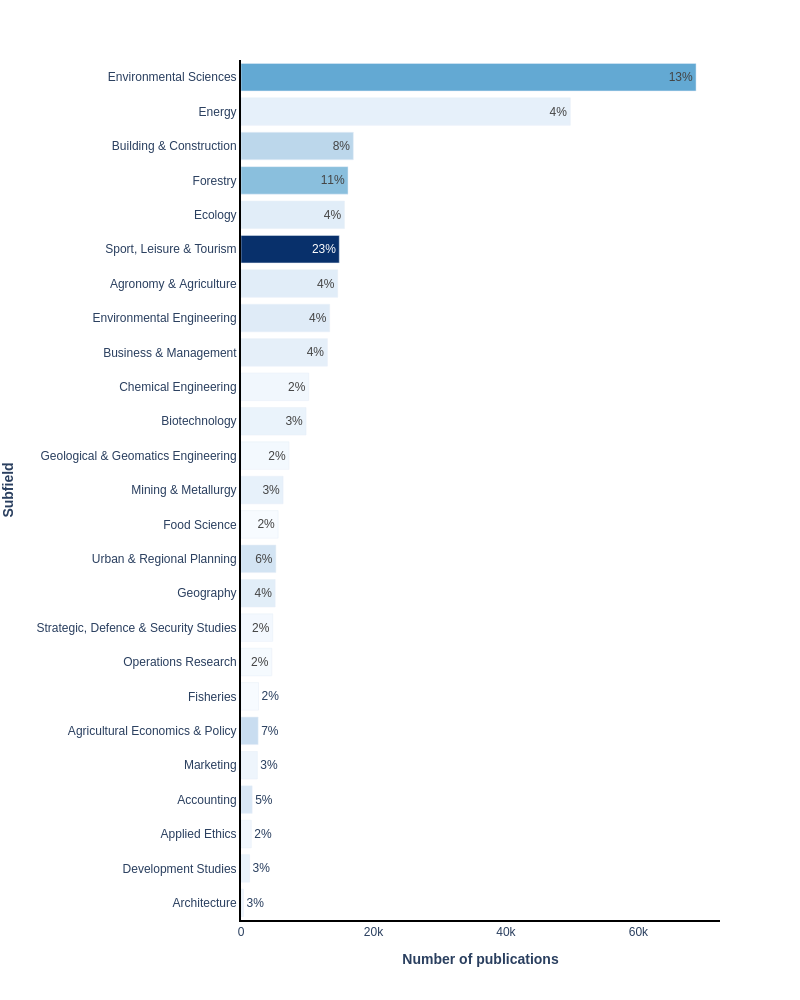

Figure 1. Top 25 subfields with the largest percentage of Scopus publication included in the publication set.

## Journals

In this section, we show how the publication set, captured by the query above, relates to scholarly journals. Journals are sorted in terms of their relevance using term frequency-inverse document frequency (TF-IDF). The horizontal bars are proportional to the number of publications contributed by the journal to the current publication set. The number alongside the horizontal bar is the proportion of the journal contributing to this publication set.

The articles on this topic are published most frequently in the following journals: *Journal of Cleaner Production* (11,938 publications), *Sustainability (Switzerland)* (10,345), and *Waste Management* (5,495).

Note, larger journals may not appear in the table below, as their SDG contribution may be relatively small compared to the size of the journal.

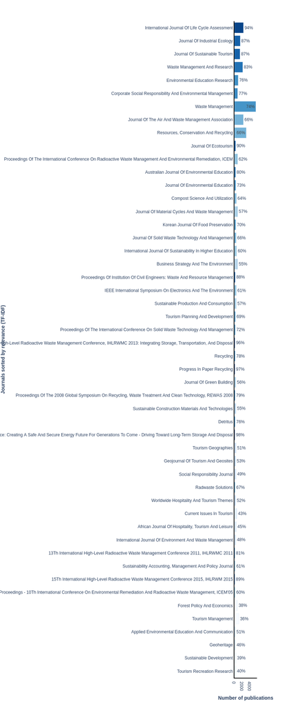

Figure 2. Top 50 journals, in terms of relevance (TF-IDF), for this publication set.

## Keywords

Elsevier’s [Scopus](https://www.scopus.com/search/form.uri?display=basic#basic) database of scientific literature, was used for the table below. The document types included in the data sets are journal articles, reviews, short surveys and conference papers, covering the period 1996–2022. We refer to these documents collectively as “publications” or “papers”.

In order to help better illustrate the content of this set of publications, indicators associated with the keywords most specific to this set (according to a TF-IDF score) are presented below.

|  | Term | # of papers with this term in the publication set | # of papers with this term in all of Scopus | Relevance (TF-IDF) | Percentage of Scopus |
| --- | --- | --- | --- | --- | --- |
| 1 | life cycle impact assessment | 1543 | 1709 | 18.7022 | 90 |
| 2 | life cycle impact | 2303 | 2576 | 18.7015 | 89 |
| 3 | municipal solid waste incineration | 1695 | 1905 | 18.685 | 89 |
| 4 | life cycle inventory | 2061 | 2333 | 18.6804 | 88 |
| 5 | zero energy building | 1900 | 2163 | 18.6681 | 88 |
| 6 | green roofs | 2271 | 2599 | 18.6586 | 87 |
| 7 | solid waste incineration | 1834 | 2102 | 18.654 | 87 |
| 8 | simapro | 1108 | 1225 | 18.6449 | 90 |
| 9 | forest management plan | 1462 | 1675 | 18.634 | 87 |
| 10 | conservation agriculture | 1950 | 2273 | 18.6249 | 86 |

[output cut: 990 more lines]